# w6a: Order Selection

[Nao Mimoto](https://nmimoto.github.io/) - [Dept. of Statistics](http://www.uakron.edu/stat/) : [The University of Akron](http://www.uakron.edu)

[Class Web Page](https://nmimoto.github.io/477/)

## Modeling Procedure:

**( Stationarity Check )** Does $X_t$ look stationary?

- perform stationarity transformation if it look stationary

**( De-mean )** Is the mean of this process 0?

- We usually de-mean, unless we have a reason to believe the true mean is equal to 0.

**( Model Selection )** What model should we use? AR(p)? or something else?

**( Order Selection )** How did we decide on the value of $p$ to fit?

- ACF and PACF
- AIC and log-likelihood
- Parameter Significance

**( Paramete Estimation )** What estimator was used for $\phi_i$? Can you reject he null hypothesis that $\phi_i=0$?

- Use $\hat \phi \pm 2(S.E.)$ CI to check significance.

**( Residual Analysis )** How was the residual calculated? What does it say about how the model fits the data?

## 1. Use ACF and PACF

ACF of AR(p) tails off PACF of AR(P) cuts off at lag $p$. Theoretical value of PACF($h$) are $\phi_h$.

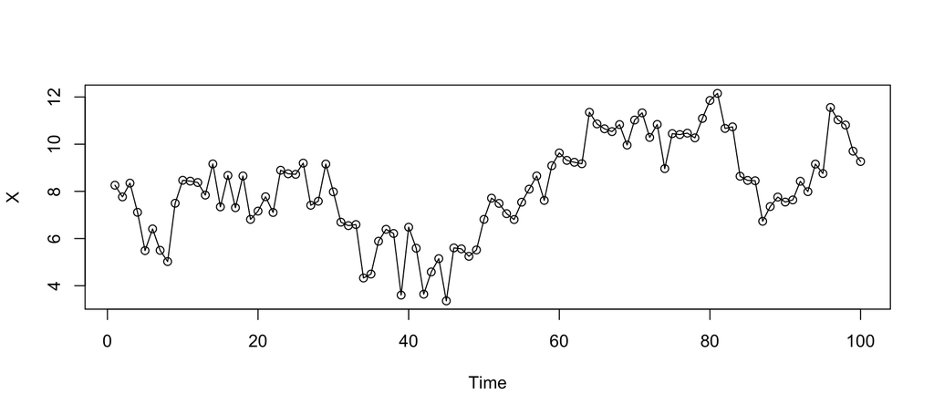

```r
  set.seed(3563)
  X = arima.sim(list(ar = c(.6, .3) ), 100)  + 8.5
  plot(X, type="o")
```

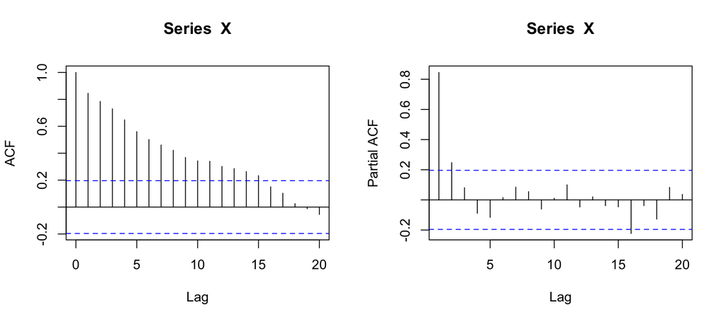

```r
  layout(matrix(1:2, 1, 2))  # two plots side by side
  acf(X)                     # plot sample ACF
  pacf(X)                    # plot sample PACF
```

```r
  layout(1)                  # return to 1 plot layout
```

## 2. Use AIC and log-likelihood

Likelihood function
$$L(\theta) = f(X_1) \, f(X_2) \, \cdots f(X_n)$$

Akaike Information Criteria:
$$\mbox{AIC} = -2 \, \log(\mbox{maximum likelihood}) + 2 k$$
$k=p+1$ if non-zero mean is included in the model, and $k=p$ if not.

Choose $p$ that **MINIMIZE** AIC.

The **auto.arima()** in **forecast** package chooses $p$ value based on AIC automatically.

### AIC Simulation Study

If we use AIC all the time, what is the probability we end up with correct $p$?

Set $p=2$. Generate simulated AR(2). Use **auto.arima(Y)** and search for best $p$ by using Minimum AIC. Repeat 1000 times. How many time do we end up with right $p$?

```r
  library(forecast)
  #- Simulation Study of choosing p by AIC
  Result = 0
  for (i in 1:1000){
    X    = arima.sim(list(ar = c(.6, .3) ), 100 )  + 8.5
    Fit7 = auto.arima(X, d=0, max.q=0)        # find AR(p) by AIC
    Result[i] = length(Fit7$model$phi)        # save value of p chosen
  }
  head(Result, 100)                       # first 100 p
```

```
##   [1] 3 2 1 2 3 2 1 3 2 2 2 2 1 2 2 3 1 2 4 2 2 3 3 2 3 1 2 3 2 2
##  [31] 2 3 2 2 2 2 2 2 2 2 2 2 2 1 2 1 2 3 2 2 2 2 1 2 2 2 1 2 2 2
##  [61] 2 2 1 1 2 2 2 2 2 2 1 2 2 2 2 2 2 2 2 2 2 2 1 1 2 2 1 1 2 2
##  [91] 2 2 2 3 2 5 2 2 2 2
```

```r
  mean(Result==2)                         # propotion of times p=2
```

```
## [1] 0.765
```

## 3. Use Parameter Significance

After $p$ was suggested by AIC, test the pameter estimate for significance using large-sample 95% CI. i.e. $\hat p \pm 2 SE$ If the last parameter is not significant, reduce $p$ by 1, and fit again.

### Ex: When AIC fails use Param Sig

If we use AIC all the time, what is the probability we end up with correct $p$?

- Set $p=2$. Generate simulated AR(2).
- Use **ar(Y)** and search for best $p$ by using Minimum AIC.
- Repeat 1000 times. How many time do we end up with right $p$?

```r
  set.seed(1532)

  #- Run until p=3 comes out
  for (i in 1:999){
    X    = arima.sim(list(ar = c(.6, .3) ), 100 )  + 8.5
    Fit7 = auto.arima(X, d=0, max.q=0)        # find AR(p) by AIC
    Result = length(Fit7$model$phi)           # save value of p chosen
    if (Result==3){
      break
    }
  }

  auto.arima(X, d=0, max.q=0)   # search for best p by AIC
```

```
## Series: X
## ARIMA(3,0,0) with non-zero mean
##
## Coefficients:
##          ar1     ar2      ar3    mean
##       0.6314  0.4514  -0.1932  8.8675
## s.e.  0.0972  0.1063   0.0990  0.8142
##
## sigma^2 = 0.9548:  log likelihood = -138.39
## AIC=286.79   AICc=287.43   BIC=299.82
```

```r
  Arima(X, order=c(2,0,0))      # fit AR(2)
```

```
## Series: X
## ARIMA(2,0,0) with non-zero mean
##
## Coefficients:
##          ar1     ar2    mean
##       0.5633  0.3466  8.9965
## s.e.  0.0928  0.0938  0.9787
##
## sigma^2 = 0.9818:  log likelihood = -140.26
## AIC=288.52   AICc=288.94   BIC=298.94
```

## Summary

- Plot ACF and PACF to get some feel for value of $p$.
- Use minumum Akaike Information Criteria (AIC) criteria to look for the best $p$. It is default in **auto.arima()**.
- Check parameter significance of estimated parameters.
- After getting the suggested “best” $p$ from AIC, fit model with p+1, and check to see if the last parameter estimate comes out non-significant.